# Optimization II - Homework Assignment 1

*Akshat Johari - aj32864*

## Importing required libraries

```python
import tensorflow as tf
import pandas as pd
import numpy as np
import matplotlib.pyplot as plt
```

## Importing MNIST dataset

```python
mnist = tf.keras.datasets.mnist

(x_train, y_train), (x_test, y_test) = mnist.load_data()
x_train = x_train / 255.0
x_test = x_test / 255.0

ndata_train = x_train.shape[0]
ndata_test = x_test.shape[0]

x_test_copy = x_test.copy()
```

## Visualizing an image in the data

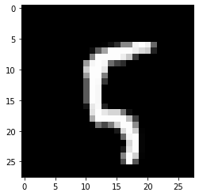

```python
plt.imshow(x_train[100,:,:], cmap = 'gray')
```

```python
x_train = x_train.reshape((ndata_train, 28, 28, 1))
x_test = x_test.reshape((ndata_test, 28, 28, 1))

xshape = x_train.shape[1:4]
```

## Model 1

```python
NNmodel1 = tf.keras.models.Sequential([
        tf.keras.layers.Flatten(input_shape=xshape),
        tf.keras.layers.Dense(64,activation=tf.nn.relu,kernel_regularizer = tf.keras.regularizers.l2(0.0004)),
        tf.keras.layers.Dropout(0.5),
        tf.keras.layers.Dense(64,activation=tf.nn.sigmoid),
        tf.keras.layers.Dense(10,activation=tf.nn.softmax)
        ])
```

```python
NNmodel1.compile(optimizer='adam',
              loss='sparse_categorical_crossentropy',
              metrics=['accuracy'])

NNmodel1.summary()
```

```
Model: "sequential"
_________________________________________________________________
 Layer (type)                Output Shape              Param #
=================================================================
 flatten (Flatten)           (None, 784)               0

 dense (Dense)               (None, 64)                50240

 dropout (Dropout)           (None, 64)                0

 dense_1 (Dense)             (None, 64)                4160

 dense_2 (Dense)             (None, 10)                650

=================================================================
Total params: 55,050
Trainable params: 55,050
Non-trainable params: 0
_________________________________________________________________
```

```python
NNmodel1.fit(x_train,y_train,epochs=12,validation_split=0.2,batch_size=200)
```

```
<keras.callbacks.History at 0x7f951e0c4190>
```

```python
print('This model predicts '+str(NNmodel1.evaluate(x_test,y_test)[1]*100) +'% of the test data correctly')
```

```
This model predicts 96.03000283241272% of the test data correctly
```

## Model 2

```python
NNmodel2 = tf.keras.models.Sequential([
        tf.keras.layers.Flatten(input_shape=xshape),
        tf.keras.layers.Dense(64,activation=tf.nn.relu,kernel_regularizer = tf.keras.regularizers.l1(0.0002)),
        tf.keras.layers.Dropout(0.1),
        tf.keras.layers.Dense(64,activation=tf.nn.sigmoid),
        tf.keras.layers.Dense(10,activation=tf.nn.softmax)
        ])
```

```python
NNmodel2.compile(optimizer='sgd',
              loss='sparse_categorical_crossentropy',
              metrics=['accuracy'])

NNmodel2.summary()
```

```
Model: "sequential_1"
_________________________________________________________________
 Layer (type)                Output Shape              Param #
=================================================================
 flatten_1 (Flatten)         (None, 784)               0

 dense_3 (Dense)             (None, 64)                50240

 dropout_1 (Dropout)         (None, 64)                0

 dense_4 (Dense)             (None, 64)                4160

 dense_5 (Dense)             (None, 10)                650

=================================================================
Total params: 55,050
Trainable params: 55,050
Non-trainable params: 0
_________________________________________________________________
```

```python
NNmodel2.fit(x_train,y_train,epochs=12,validation_split=0.2,batch_size=200)
```

```
<keras.callbacks.History at 0x7f9519844250>
```

```python
print('This model predicts '+str(NNmodel2.evaluate(x_test,y_test)[1]*100) +'% of the test data correctly')
```

```
This model predicts 86.08999848365784% of the test data correctly
```

## Model 3

- Convolutional layer - 64 nodes, 3x3 kernel, ReLU activation
- Max pooling - 2x2 pool size
- Flatten
- Dropout (0.1)
- Dense (64 nodes, sigmoid activation)
- Dense (10 nodes, softmax activation)
- Optimizer - adagrad
- Epochs - 12
- Batch size - 200
- Validation size - 20%
- Test set accuracy - 82.14%

```python
NNmodel3 = tf.keras.models.Sequential([
        tf.keras.layers.Conv2D(filters = 64, kernel_size = (3,3), activation = 'relu', input_shape=xshape),
        tf.keras.layers.MaxPooling2D(pool_size = (2,2)),
        tf.keras.layers.Flatten(),
        tf.keras.layers.Dropout(0.1),
        tf.keras.layers.Dense(64,activation=tf.nn.sigmoid),
        tf.keras.layers.Dense(10,activation=tf.nn.softmax)
        ])
```

```python
NNmodel3.compile(optimizer='adagrad',
              loss='sparse_categorical_crossentropy',
              metrics=['accuracy'])

NNmodel3.summary()
```

```
Model: "sequential_5"
_________________________________________________________________
 Layer (type)                Output Shape              Param #
=================================================================
 conv2d_3 (Conv2D)           (None, 26, 26, 64)        640

 max_pooling2d_3 (MaxPooling  (None, 13, 13, 64)       0
 2D)

 flatten_3 (Flatten)         (None, 10816)             0

 dropout_5 (Dropout)         (None, 10816)             0

 dense_12 (Dense)            (None, 64)                692288

 dense_13 (Dense)            (None, 10)                650

=================================================================
Total params: 693,578
Trainable params: 693,578
Non-trainable params: 0
_________________________________________________________________
```

```python
NNmodel3.fit(x_train,y_train,epochs=12,validation_split=0.2,batch_size=200)
```

```
<keras.callbacks.History at 0x7f95188bf3d0>
```

```python
print('This model predicts '+str(NNmodel3.evaluate(x_test,y_test)[1]*100) +'% of the test data correctly')
```

```
This model predicts 82.1399986743927% of the test data correctly
```

## Model 4

- Convolution - 32 nodes, 3x3 kernel, ReLU activation
- MaxPooling - 2x2 pool
- Dropout - 25%
- Convolution - 64 nodes, 3x3 kernel, ReLU activation
- MaxPooling - 2x2 pool
- Dropout - 25%
- Convolution - 128 nodes, 3x3 kernel, ReLU activation
- MaxPooling - 2x2 pool
- Dropout - 25%
- Flatten
- Dense - 256 layers, ReLU activation
- Dropout - 25%
- Dense - 10 nodes (1 per output), softmax activation
- Epochs - 20
- Batch size - 50
- Validation size - 20%
- Test set accuracy - 98.95%

```python
NNmodel4 = tf.keras.models.Sequential([
        tf.keras.layers.Conv2D(filters = 32, kernel_size = (3,3), activation = 'relu', input_shape=xshape),
        tf.keras.layers.MaxPooling2D(pool_size = (2,2)),
        tf.keras.layers.Dropout(0.25),

        tf.keras.layers.Conv2D(filters = 64, kernel_size = (3,3), activation = 'relu', input_shape=xshape),
        tf.keras.layers.MaxPooling2D(pool_size = (2,2)),
        tf.keras.layers.Dropout(0.25),

        tf.keras.layers.Conv2D(filters = 128, kernel_size = (3,3), activation = 'relu', input_shape=xshape),
        tf.keras.layers.MaxPooling2D(pool_size = (2,2)),
        tf.keras.layers.Dropout(0.25),

        tf.keras.layers.Flatten(),

        tf.keras.layers.Dense(256,activation='relu'),
        tf.keras.layers.Dropout(0.25),
        tf.keras.layers.Dense(10,activation=tf.nn.softmax)
        ])
```

```python
NNmodel4.compile(optimizer='adam',
              loss='sparse_categorical_crossentropy',
              metrics=['accuracy'])

NNmodel4.summary()
```

```
Model: "sequential_6"
_________________________________________________________________
 Layer (type)                Output Shape              Param #
=================================================================
 conv2d_7 (Conv2D)           (None, 26, 26, 32)        320

 max_pooling2d_7 (MaxPooling  (None, 13, 13, 32)       0
 2D)

 dropout_9 (Dropout)         (None, 13, 13, 32)        0

 conv2d_8 (Conv2D)           (None, 11, 11, 64)        18496

 max_pooling2d_8 (MaxPooling  (None, 5, 5, 64)         0
 2D)

 dropout_10 (Dropout)        (None, 5, 5, 64)          0

 conv2d_9 (Conv2D)           (None, 3, 3, 128)         73856

 max_pooling2d_9 (MaxPooling  (None, 1, 1, 128)        0
 2D)

 dropout_11 (Dropout)        (None, 1, 1, 128)         0

 flatten_5 (Flatten)         (None, 128)               0

 dense_15 (Dense)            (None, 256)               33024

 dropout_12 (Dropout)        (None, 256)               0

 dense_16 (Dense)            (None, 10)                2570

=================================================================
Total params: 128,266
Trainable params: 128,266
Non-trainable params: 0
_________________________________________________________________
```

```python
NNmodel4.fit(x_train,y_train,epochs=20,validation_split=0.2,batch_size=50)
```

```
<keras.callbacks.History at 0x7f95186c8290>
```

```python
print('This model predicts '+str(NNmodel4.evaluate(x_test,y_test)[1]*100) +'% of the test data correctly')
```

```
This model predicts 98.94999861717224% of the test data correctly
```

## Model 5

- Convolution - 32 nodes, 3x3 kernel, ReLU activation
- MaxPooling - 2x2 pool
- Dropout - 30%
- Convolution - 64 nodes, 3x3 kernel, ReLU activation
- MaxPooling - 2x2 pool
- Dropout - 30%
- Convolution - 128 nodes, 3x3 kernel, ReLU activation
- MaxPooling - 2x2 pool
- Dropout - 30%
- Flatten
- Dense - 256 layers, ReLU activation
- Dropout - 30%
- Dense - 10 nodes (1 per output), softmax activation
- Epochs - 20
- Batch size - 50
- Validation size - 20%
- Test set accuracy - 99.03%

```python
NNmodel5 = tf.keras.models.Sequential([
        tf.keras.layers.Conv2D(filters = 32, kernel_size = (3,3), activation = 'relu', input_shape=xshape),
        tf.keras.layers.MaxPooling2D(pool_size = (2,2)),
        tf.keras.layers.Dropout(0.3),

        tf.keras.layers.Conv2D(filters = 64, kernel_size = (3,3), activation = 'relu', input_shape=xshape),
        tf.keras.layers.MaxPooling2D(pool_size = (2,2)),
        tf.keras.layers.Dropout(0.3),

        tf.keras.layers.Conv2D(filters = 128, kernel_size = (3,3), activation = 'relu', input_shape=xshape),
        tf.keras.layers.MaxPooling2D(pool_size = (2,2)),
        tf.keras.layers.Dropout(0.3),

        tf.keras.layers.Flatten(),

        tf.keras.layers.Dense(256,activation='relu'),
        tf.keras.layers.Dropout(0.3),
        tf.keras.layers.Dense(10,activation=tf.nn.softmax)
        ])
```

```python
NNmodel5.compile(optimizer='adam',
              loss='sparse_categorical_crossentropy',
              metrics=['accuracy'])
# sparse categorical cross-entropy removes the requirement for us to do one-hot encoding

NNmodel5.summary()
```

```
Model: "sequential_7"
_________________________________________________________________
 Layer (type)                Output Shape              Param #
=================================================================
 conv2d_10 (Conv2D)          (None, 26, 26, 32)        320

 max_pooling2d_10 (MaxPoolin  (None, 13, 13, 32)       0
 g2D)

 dropout_13 (Dropout)        (None, 13, 13, 32)        0

 conv2d_11 (Conv2D)          (None, 11, 11, 64)        18496

 max_pooling2d_11 (MaxPoolin  (None, 5, 5, 64)         0
 g2D)

 dropout_14 (Dropout)        (None, 5, 5, 64)          0

 conv2d_12 (Conv2D)          (None, 3, 3, 128)         73856

 max_pooling2d_12 (MaxPoolin  (None, 1, 1, 128)        0
 g2D)

 dropout_15 (Dropout)        (None, 1, 1, 128)         0

 flatten_6 (Flatten)         (None, 128)               0

 dense_17 (Dense)            (None, 256)               33024

 dropout_16 (Dropout)        (None, 256)               0

 dense_18 (Dense)            (None, 10)                2570

=================================================================
Total params: 128,266
Trainable params: 128,266
Non-trainable params: 0
_________________________________________________________________
```

```python
NNmodel5.fit(x_train,y_train,epochs=20,validation_split=0.2,batch_size=50)
```

```
<keras.callbacks.History at 0x7f951854e810>
```

```python
print('This model predicts '+str(NNmodel5.evaluate(x_test,y_test)[1]*100) +'% of the test data correctly')
```

```
This model predicts 99.02999997138977% of the test data correctly
```

## Training on entire training set

```python
NNmodel5.fit(x_train,y_train,epochs=20,batch_size=50)
```

```
<keras.callbacks.History at 0x7f9510a6fc50>
```

```python
print('This model predicts '+str(NNmodel5.evaluate(x_test,y_test)[1]*100) +'% of the test data correctly')
```

```
This model predicts 99.15000200271606% of the test data correctly
```

```python
pred = NNmodel5.predict(x_test)
pred
```

```
array([[3.63574425e-14, 5.26470256e-10, 1.64689240e-07, ...,
        9.99999881e-01, 1.80792305e-14, 8.08101974e-10],
       [2.06233217e-08, 2.56971106e-07, 9.99997020e-01, ...,
        2.56863905e-06, 7.78667939e-08, 1.90531466e-10],
       [5.59328051e-08, 9.99989510e-01, 5.52372239e-06, ...,
        8.10787355e-07, 1.38333871e-06, 1.46975578e-08],
       ...,
       [5.60317413e-19, 1.13580130e-15, 1.25957918e-15, ...,
        1.34356924e-12, 4.46183368e-11, 2.16229829e-11],
       [2.04018774e-10, 2.60984168e-11, 8.73658107e-14, ...,
        6.43742499e-16, 4.07585468e-08, 8.61151417e-09],
       [1.10648816e-10, 1.85303992e-14, 9.80721472e-13, ...,
        2.35021044e-20, 1.20766286e-10, 1.40765915e-12]], dtype=float32)
```

```python
incorrect = []
for i in range(len(pred)):
    if pred[i].argmax() != y_test[i]:
        incorrect.append(i)
```

```python
error_set = {}
for i in incorrect:
    if str(pred[i].argmax()) + ' mistaken for ' + str(y_test[i]) not in error_set:
        error_set[str(pred[i].argmax()) + ' mistaken for ' + str(y_test[i])] = 1
    else:
        error_set[str(pred[i].argmax()) + ' mistaken for ' + str(y_test[i])] += 1
error_set
```

```
{'0 mistaken for 2': 1,
 '0 mistaken for 5': 1,
 '0 mistaken for 6': 3,
 '1 mistaken for 0': 1,
 '1 mistaken for 6': 2,
 '1 mistaken for 7': 2,
 '1 mistaken for 8': 1,
 '2 mistaken for 0': 1,
 '2 mistaken for 3': 2,
 '2 mistaken for 6': 1,
 '2 mistaken for 7': 3,
 '2 mistaken for 8': 1,
 '3 mistaken for 2': 1,
 '3 mistaken for 5': 3,
 '3 mistaken for 8': 2,
 '4 mistaken for 6': 1,
 '4 mistaken for 8': 1,
 '4 mistaken for 9': 3,
 '5 mistaken for 3': 3,
 '5 mistaken for 6': 1,
 '5 mistaken for 7': 1,
 '5 mistaken for 9': 3,
 '6 mistaken for 0': 1,
 '6 mistaken for 2': 1,
 '6 mistaken for 4': 3,
 '6 mistaken for 5': 2,
 '6 mistaken for 9': 1,
 '7 mistaken for 0': 2,
 '7 mistaken for 1': 2,
 '7 mistaken for 2': 10,
 '7 mistaken for 3': 1,
 '7 mistaken for 5': 1,
 '7 mistaken for 8': 1,
 '7 mistaken for 9': 7,
 '8 mistaken for 6': 2,
 '8 mistaken for 9': 3,
 '9 mistaken for 0': 1,
 '9 mistaken for 4': 6,
 '9 mistaken for 8': 3}
```

## Insights

This model predicts the test set with 99.15% accuracy, which is fantastic.  
As can be seen, the most frequent errors made by the model are:

1. 7 mistaken for 2 (10 times)
2. 7 mistaken for 9 (7 times)
3. 9 mistaken for 4 (6 times)

I have visualized all the numbers that were incorrectly labeled by the model below. The numbers that the model misidentified would have likely also caused confusion to any human trying to identify what the actual number was (maybe the number was written by a doctor!)

7 and 2 can easily be confused, as can 7 and 9.  
9 for 4 may be due to the top ends of the 4 being close enough that it looks like a 9.

It is possible to get 100% accuracy (in fact, Slava Moiseev has documented his model with 0 test set errors [here](https://medium.com/@vbm1973/classification-of-mnist-data-with-100-accuracy-d8037a43eebb)). The way he did it was he trained separate models to identify each number, and then created an ensemble model incorporating all of the individual models.

```
Actual image:
```

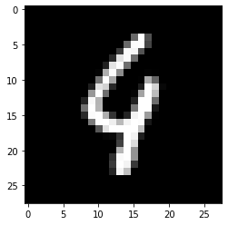

```
Predicted value: 9
--------------------------------------------------

Actual image:
```

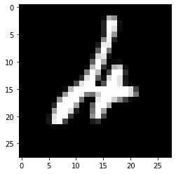

```
Predicted value: 6
--------------------------------------------------

Actual image:
```

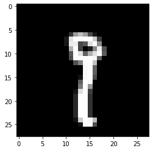

```
Predicted value: 8
--------------------------------------------------

Actual image:
```

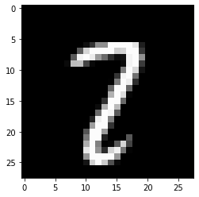

```
Predicted value: 7
--------------------------------------------------

Actual image:
```

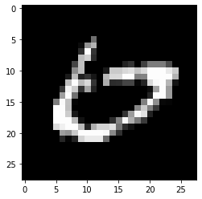

```
Predicted value: 0
--------------------------------------------------

Actual image:
```

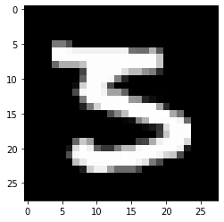

```
Predicted value: 5
--------------------------------------------------

Actual image:
```

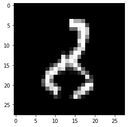

```
Predicted value: 2
--------------------------------------------------

Actual image:
```

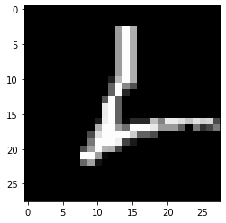

```
Predicted value: 6
--------------------------------------------------

Actual image:
```

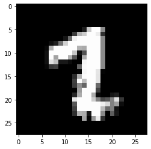

```
Predicted value: 7
--------------------------------------------------

Actual image:
```

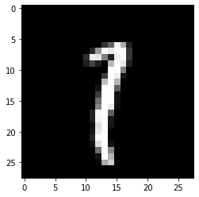

```
Predicted value: 7
--------------------------------------------------

Actual image:
```

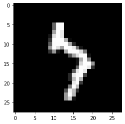

```
Predicted value: 5
--------------------------------------------------

Actual image:
```

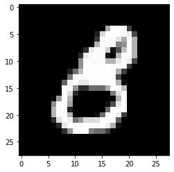

```
Predicted value: 3
--------------------------------------------------

Actual image:
```

[73 more figures not shown]

```
Predicted value: 9
--------------------------------------------------
```

```python
for i in incorrect:
    print('\nActual image:\n')
    plt.imshow(x_test_copy[i,:,:], cmap = 'gray');
    plt.show();

    print('\nPredicted value:', pred[i].argmax())
    print('-'*50)
```